# Data Visualizations Static Graphs

Ratul Esrar

10/29/2017

```
## [1] TRUE
```

### Graph 1: Are federally reported inflation rates in the US underestimated?

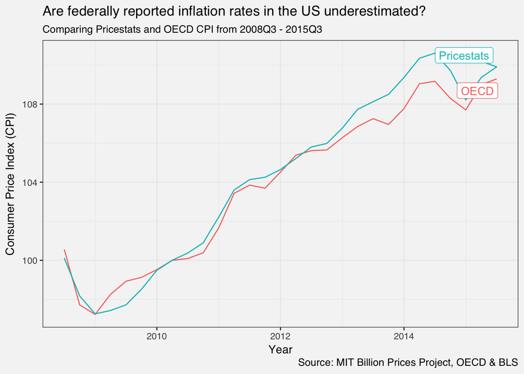

Using daily consumer price index calculations calculated by the Pricestats database is arguably a more precise measure of inflation than quarterly reports by the Bureau of Labor Statistics. Looking at quarterly CPI reports relative to the average of daily CPI calculations per quarter from Pricestats shows an interesting relationship, especially during times of recession. The Pricestats CPI is generally higher than the OECD report except during recession periods.

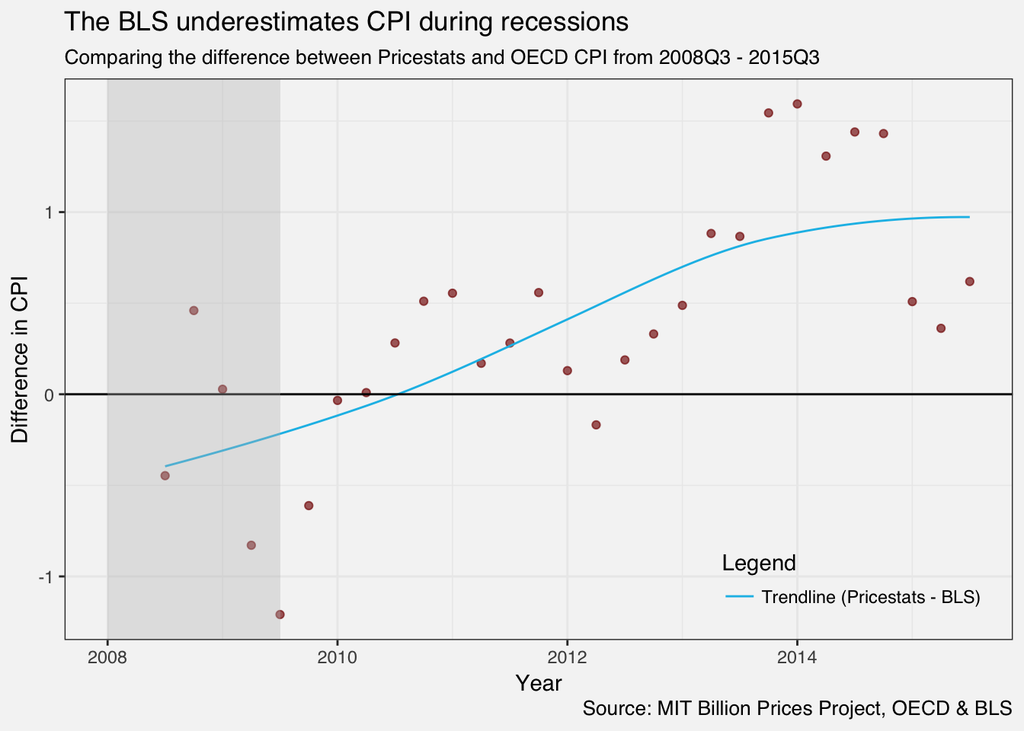

Looking more closely at the differences between the OECD’s reported CPI, which is taken from the BLS, and the Pricestats CPI database, we see two interesting things. First, the CPI is trending upward and that makes sense as the United States has not been in a period of deflation since 2008Q3. Second, the difference between Pricestats CPI and OECD CPI is negative during the 2008 recession but has been positive in almost every period since then. It is possible that the BLS has incentive to overestimate CPI during periods of economic stagnation to artificially indicate economic growth.

### Graph 3: Changes in Personal Income Outpaced Change in Inflation

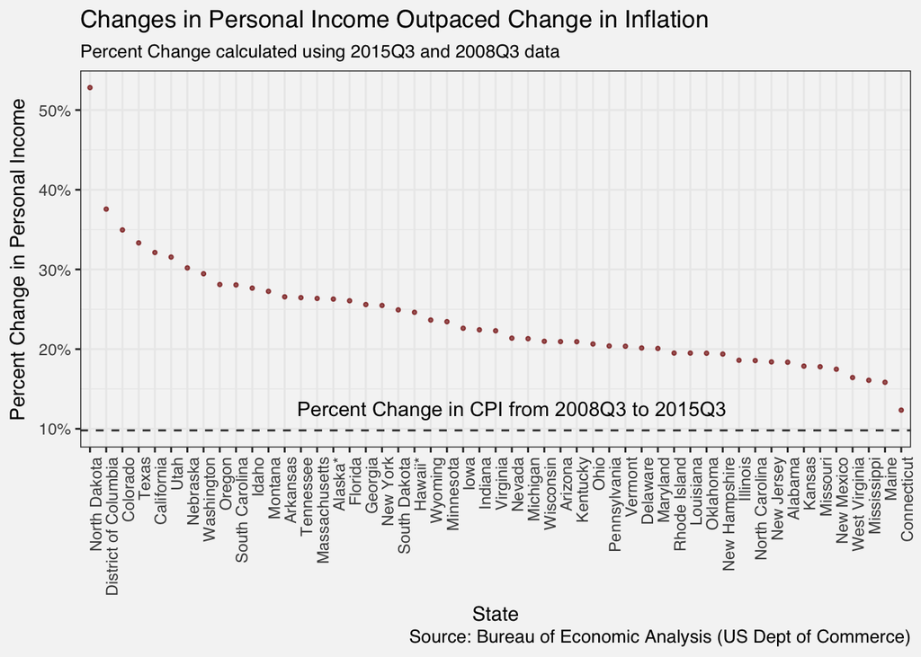

When examining difference in CPI over time, it is also prudent to look at changes to income, or in this case, aggregate personal income by state (seasonally adjusted). Over the time period of this data, the median change in total personal income by state was around 23 percent, while the CPI only increased by 10 percent in the same period of time. It’s possible that total personal income is skewed due to the top earners in each state, which may be why that change seems much larger than the change in inflation.

### Graph 4: Income Distribution Has Not Kept Pace with CPI

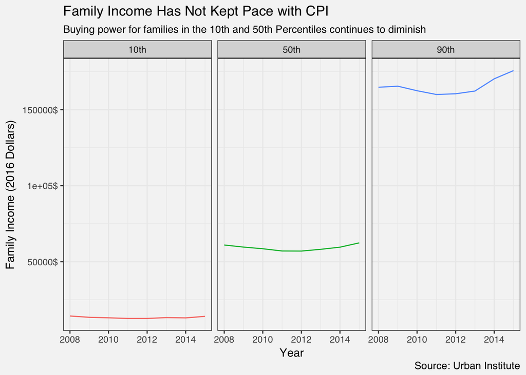

Disaggregating personal income from graph 3 helps display the growing wealth disparities betweens people in the tails of the income distribution. The 10th and 50th percentile families have experienced little rises in income, while the 90th percentile incomes have increased steadily since 2012.

### Graph 5: Median Household Income Varies Greatly from State to State

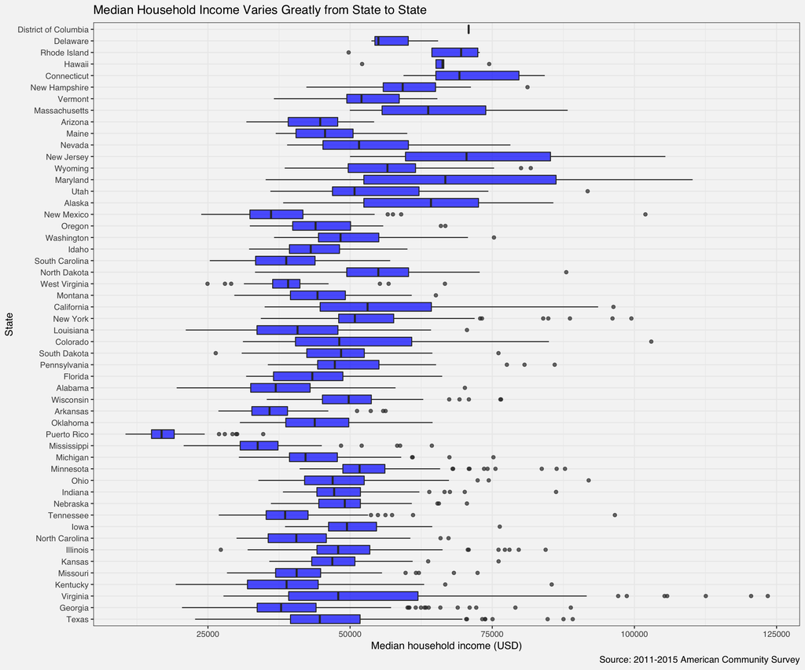

### Graph 6: The Northeast United States Have Higher median Incomes

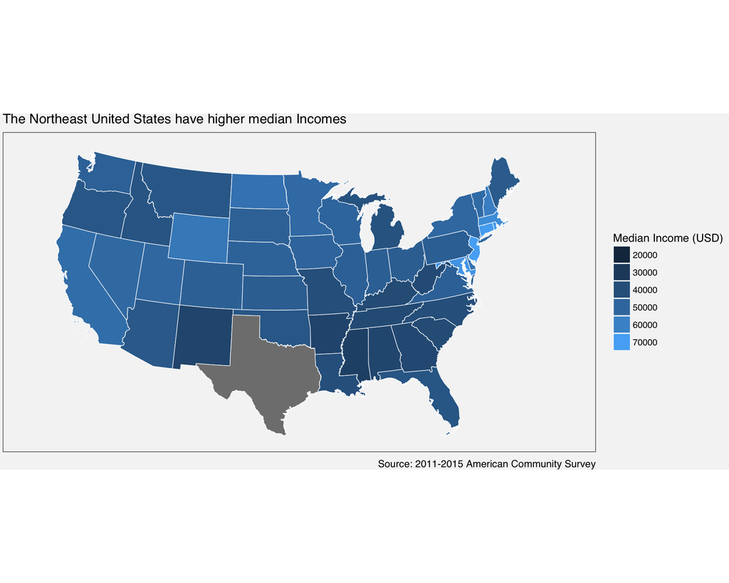

### Graph 7: Percent of Population in Poverty Varies Immensely by Region

[figure not shown]